# Homework 2: DIFFERENTIAL GENE EXPRESSION, CLUSTERING ANALYSIS

Marko Ludaic, Denis Expósito Navarro

Last update: 20 February, 2023

## Clustering gene expression data in healthy tissues

Download the [data](https://www.ebi.ac.uk/biostudies/arrayexpress/studies/E-MTAB-6081) (design and tpm files) corresponding to the publication [An RNASeq normal tissue atlas for mouse and rat](https://www.nature.com/articles/sdata2017185). Download the [gene expression data](https://storage.googleapis.com/gtex_analysis_v8/rna_seq_data/GTEx_Analysis_2017-06-05_v8_RNASeQCv1.1.9_gene_median_tpm.gct.gz) corresponding to the publication [The Genotype-Tissue Expression (GTEx) pilot analysis: multitissue gene regulation in humans](https://www.science.org/doi/10.1126/science.1262110) from the [GTEX portal](https://gtexportal.org/home/datasets)

[output not shown]

[output not shown]

**pro tip** Do not manually copy from the column names. Convert all column names from GTEX data to lower case, and split them appropriately.

```
## 'data.frame':    56200 obs. of  27 variables:
##  $ brain - amygdala                         : chr  "0" "1.43859" "0" "0" ...
##  $ brain - anterior cingulate cortex (ba24) : chr  "0" "1.69285" "0" "0" ...
##  $ brain - caudate (basal ganglia)          : chr  "0" "1.56605" "0" "0.0242641" ...
##  $ brain - cerebellar hemisphere            : chr  "0" "4.99231" "0" "0" ...
##  $ brain - cerebellum                       : chr  "0" "5.72099" "0" "0" ...
##  $ brain - cortex                           : chr  "0" "2.48317" "0" "0.027366" ...
##  $ brain - frontal cortex (ba9)             : chr  "0" "2.14667" "0" "0.0303822" ...
##  $ brain - hippocampus                      : chr  "0" "1.68599" "0" "0" ...
##  $ brain - hypothalamus                     : chr  "0" "1.74811" "0" "0.0247143" ...
##  $ brain - nucleus accumbens (basal ganglia): chr  "0" "1.53899" "0" "0.0306685" ...
##  $ brain - putamen (basal ganglia)          : chr  "0" "1.44167" "0" "0.0234739" ...
##  $ brain - spinal cord (cervical c-1)       : chr  "0" "2.73049" "0" "0" ...
##  $ brain - substantia nigra                 : chr  "0" "1.74194" "0" "0.0195261" ...
##  $ colon - sigmoid                          : chr  "0" "4.64777" "0" "0" ...
##  $ colon - transverse                       : chr  "0" "3.59509" "0" "0" ...
##  $ esophagus - gastroesophageal junction    : chr  "0" "4.32641" "0" "0" ...
##  $ esophagus - mucosa                       : chr  "0" "3.11749" "0" "0" ...
##  $ esophagus - muscularis                   : chr  "0" "4.10335" "0" "0" ...
##  $ heart - atrial appendage                 : chr  "0" "1.52031" "0" "0" ...
##  $ heart - left ventricle                   : chr  "0" "0.924962" "0" "0.0178934" ...
##  $ kidney - cortex                          : chr  "0" "2.77081" "0" "0.0176647" ...
##  $ kidney - medulla                         : chr  "0" "2.21451" "0" "0" ...
##  $ liver                                    : chr  "0" "1.76541" "0" "0" ...
##  $ muscle - skeletal                        : chr  "0" "1.41667" "0" "0" ...
##  $ pancreas                                 : chr  "0" "1.80871" "0" "0" ...
##  $ small intestine - terminal ileum         : chr  "0" "4.19378" "0" "0" ...
##  $ stomach                                  : chr  "0" "3.06248" "0" "0" ...
```

```
##  [1] brain - amygdala
##  [2] brain - anterior cingulate cortex (ba24)
##  [3] brain - caudate (basal ganglia)
##  [4] brain - cerebellar hemisphere
##  [5] brain - cerebellum
##  [6] brain - cortex
##  [7] brain - frontal cortex (ba9)
##  [8] brain - hippocampus
##  [9] brain - hypothalamus
## [10] brain - nucleus accumbens (basal ganglia)
## [11] brain - putamen (basal ganglia)
## [12] brain - spinal cord (cervical c-1)
## [13] brain - substantia nigra
## [14] colon - sigmoid
## [15] colon - transverse
## [16] esophagus - gastroesophageal junction
## [17] esophagus - mucosa
## [18] esophagus - muscularis
## [19] heart - atrial appendage
## [20] heart - left ventricle
## [21] kidney - cortex
## [22] kidney - medulla
## [23] liver
## [24] muscle - skeletal
## [25] pancreas
## [26] small intestine - terminal ileum
## [27] stomach
## <0 rows> (or 0-length row.names)
```

```
##  [1] x199_1_pancreas    x199_2_liver       x199_3_stomach     x199_4_duodenum
##  [5] x199_5_jejunum     x199_6_ileum       x199_7_colon       x199_8_kidney
##  [9] x199_9_quadriceps  x199_10_thymus     x199_11_heart      x199_12_esophagus
## [13] x199_13_brain      x199_14_pancreas   x199_15_liver      x199_16_stomach
## [17] x199_17_duodenum   x199_18_jejunum    x199_19_ileum      x199_20_colon
## [21] x199_21_kidney     x199_22_quadriceps x199_23_thymus     x199_24_heart
## [25] x199_25_esophagus  x199_26_brain      x199_27_pancreas   x199_28_liver
## [29] x199_29_stomach    x199_30_duodenum   x199_31_jejunum    x199_32_ileum
## [33] x199_33_colon      x199_34_kidney     x199_35_quadriceps x199_36_thymus
## [37] x199_37_heart      x199_38_esophagus  x199_39_brain
## <0 rows> (or 0-length row.names)
```

```
##  [1] x199_40_pancreas   x199_41_liver      x199_42_stomach    x199_43_duodenum
##  [5] x199_44_jejunum    x199_45_ileum      x199_46_colon      x199_47_kidneys
##  [9] x199_48_quadriceps x199_49_thymus     x199_50_heart      x199_51_esophagus
## [13] x199_52_brain      x199_53_pancreas   x199_54_liver      x199_55_stomach
## [17] x199_56_duodenum   x199_57_jejunum    x199_58_ileum      x199_59_colon
## [21] x199_60_kidneys    x199_61_quadriceps x199_62_thymus     x199_63_heart
## [25] x199_64_esophagus  x199_65_brain      x199_66_pancreas   x199_67_liver
## [29] x199_68_stomach    x199_69_duodenum   x199_70_jejunum    x199_71_ileum
## [33] x199_72_colon      x199_73_kidneys    x199_74_quadriceps x199_75_thymus
## [37] x199_76_heart      x199_77_esophagus  x199_78_brain      x199_79_unknown
## <0 rows> (or 0-length row.names)
```

```
## Ensembl site unresponsive, trying asia mirror
```

- The code above is used to obtain the IDs from biomaRt database and R library by searching for orthologue genes.
- In the data frame for species mouse and rat there is a certain number of samples for each tissue (duplicates, or triplicates), so the median is used across those replicates and the data frame is modified accordingly, since the human data frame is median.tpm as well. Furthermore, column names of both data frames are changed to indicate which species tissues belong to.
- In this part threshold are set to exclude the outliers of each species’ data frame and later on to remove genes with low expression levels by filtering gene expression data based on the mean.

[output not shown]

[output cut: 128 more lines]

- Three data frames are merged by their common gene_symbol_X columns. After sorting the new obtained data frame with data for all species, scaling was done and the data frame was made ready for clustering.

### Cluster tissues using gene expression data. Run k-means and hierarchical clustering. For each algorithm, determine the optimal number of clusters.

```
##
## Call:
## hclust(d = d_h, method = "complete")
##
## Cluster method   : complete
## Distance         : euclidean
## Number of objects: 53
```

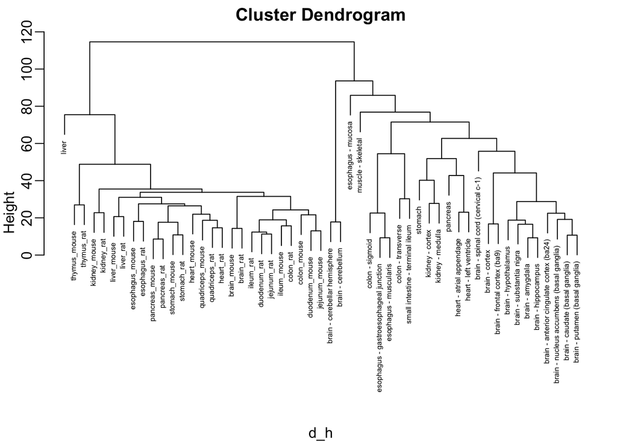

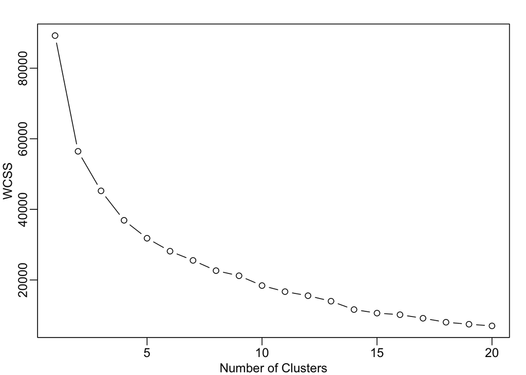

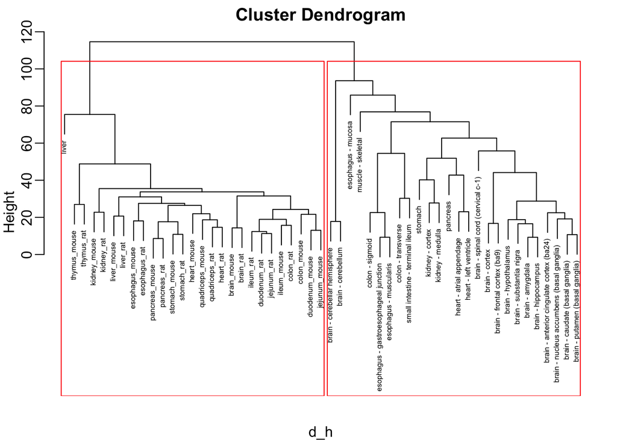

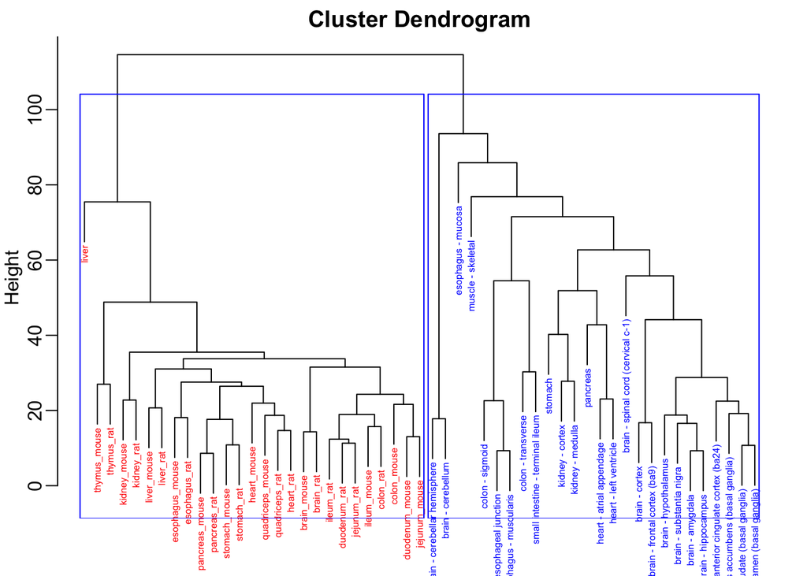

- By performing hierarchical clustering technique we have obtained 2 clusters, even tho we have expected to obtain 3 clusters, each for one species we observed. It seems like the gene expression across tissues is more similar between mouse and rat species, so they tend to group together. We have tried several ways of filtering and scaling the data so the three cluster could be obtained, but the only way was when we scaled only rat data before merging all data frames, which is not appropriate method when performing this analysis.

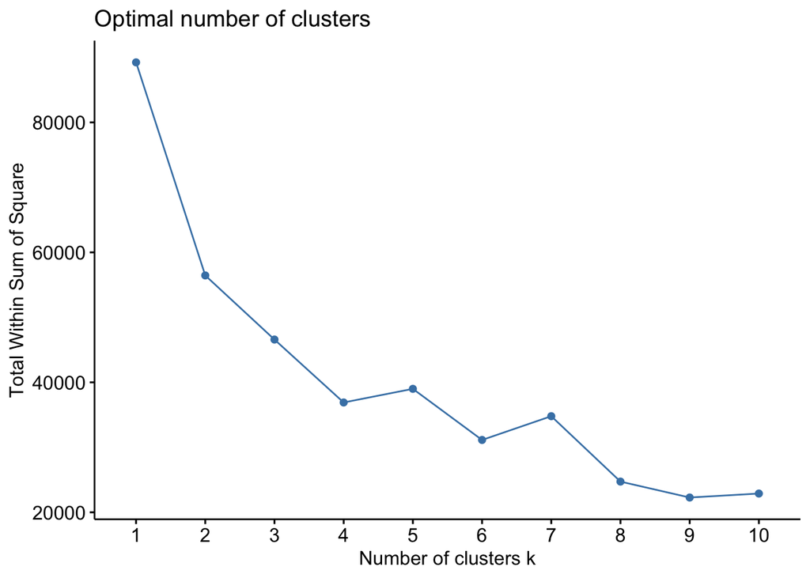

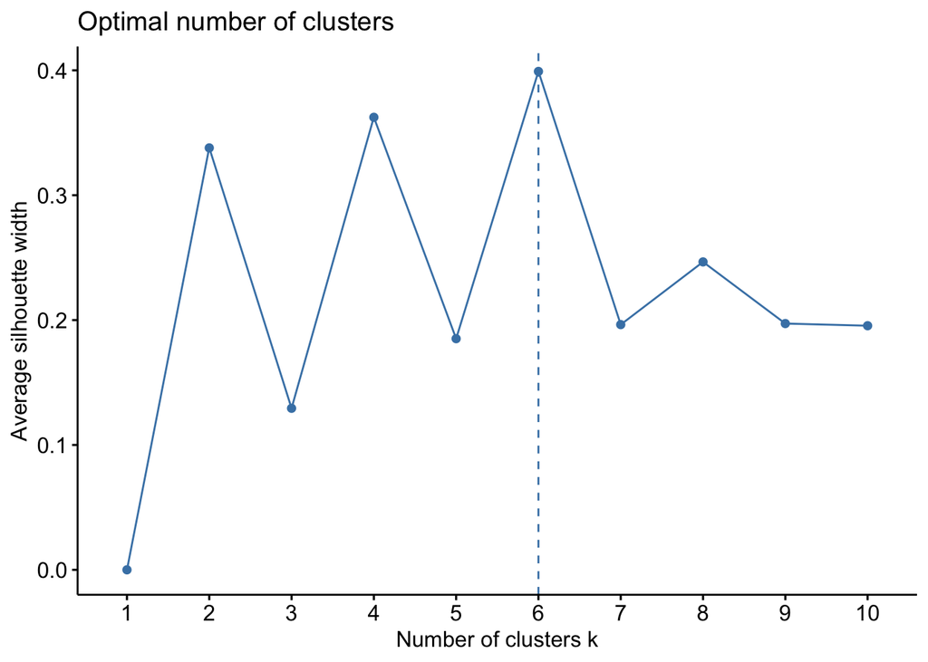

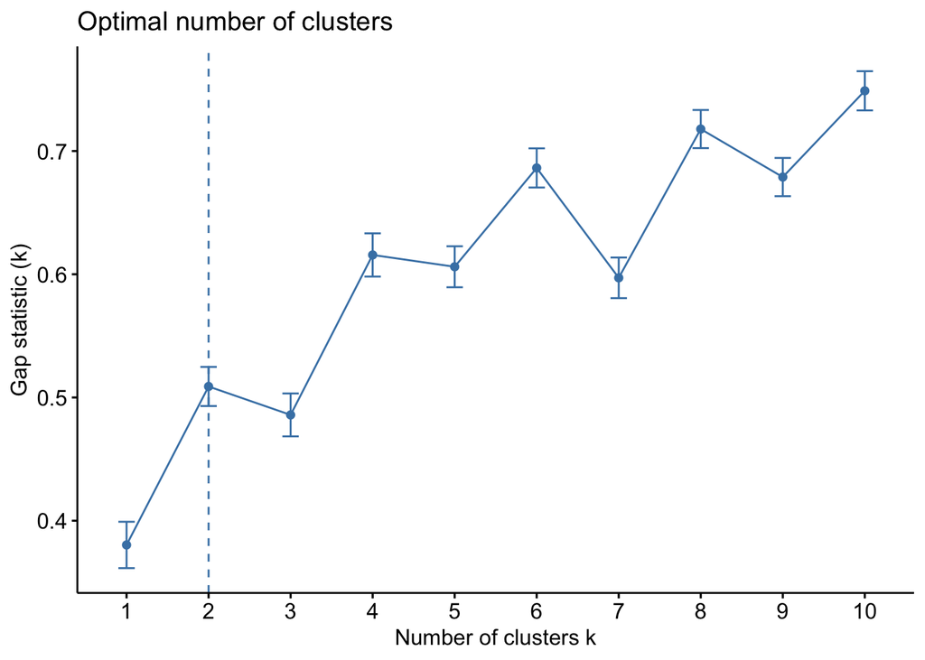

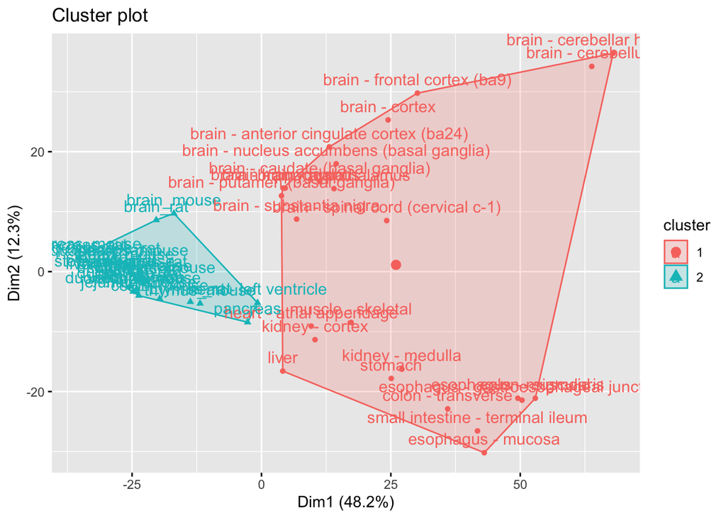

### Compare the clustering results using both methodologies, and with the tissues/species. Show the results of the final partitions as a table.

```
##                                           1 2
## colon_mouse                               0 1
## ileum_mouse                               0 1
## duodenum_mouse                            0 1
## jejunum_mouse                             0 1
## pancreas_mouse                            0 1
## liver_mouse                               0 1
## stomach_mouse                             0 1
## kidney_mouse                              0 1
## quadriceps_mouse                          0 1
## thymus_mouse                              0 1
## heart_mouse                               0 1
## esophagus_mouse                           0 1
## brain_mouse                               0 1
## colon_rat                                 0 1
## ileum_rat                                 0 1
## duodenum_rat                              0 1
## jejunum_rat                               0 1
## pancreas_rat                              0 1
## liver_rat                                 0 1
## stomach_rat                               0 1
## kidney_rat                                0 1
## quadriceps_rat                            0 1
## thymus_rat                                0 1
## heart_rat                                 0 1
## esophagus_rat                             0 1
## brain_rat                                 0 1
## brain - amygdala                          1 0
## brain - anterior cingulate cortex (ba24)  1 0
## brain - caudate (basal ganglia)           1 0
## brain - cerebellar hemisphere             1 0
## brain - cerebellum                        1 0
## brain - cortex                            1 0
## brain - frontal cortex (ba9)              1 0
## brain - hippocampus                       1 0
## brain - hypothalamus                      1 0
## brain - nucleus accumbens (basal ganglia) 1 0
## brain - putamen (basal ganglia)           1 0
## brain - spinal cord (cervical c-1)        1 0
## brain - substantia nigra                  1 0
## colon - sigmoid                           1 0
## colon - transverse                        1 0
## esophagus - gastroesophageal junction     1 0
## esophagus - mucosa                        1 0
## esophagus - muscularis                    1 0
## heart - atrial appendage                  1 0
## heart - left ventricle                    0 1
## kidney - cortex                           1 0
## kidney - medulla                          1 0
## liver                                     1 0
## muscle - skeletal                         1 0
## pancreas                                  0 1
## small intestine - terminal ileum          1 0
## stomach                                   1 0
```

```
##                                           1 2
## brain - amygdala                          0 1
## brain - anterior cingulate cortex (ba24)  0 1
## brain - caudate (basal ganglia)           0 1
## brain - cerebellar hemisphere             0 1
## brain - cerebellum                        0 1
## brain - cortex                            0 1
## brain - frontal cortex (ba9)              0 1
## brain - hippocampus                       0 1
## brain - hypothalamus                      0 1
## brain - nucleus accumbens (basal ganglia) 0 1
## brain - putamen (basal ganglia)           0 1
## brain - spinal cord (cervical c-1)        0 1
## brain - substantia nigra                  0 1
## brain_mouse                               1 0
## brain_rat                                 1 0
## colon - sigmoid                           0 1
## colon - transverse                        0 1
## colon_mouse                               1 0
## colon_rat                                 1 0
## duodenum_mouse                            1 0
## duodenum_rat                              1 0
## esophagus - gastroesophageal junction     0 1
## esophagus - mucosa                        0 1
## esophagus - muscularis                    0 1
## esophagus_mouse                           1 0
## esophagus_rat                             1 0
## heart - atrial appendage                  0 1
## heart - left ventricle                    0 1
## heart_mouse                               1 0
## heart_rat                                 1 0
## ileum_mouse                               1 0
## ileum_rat                                 1 0
## jejunum_mouse                             1 0
## jejunum_rat                               1 0
## kidney - cortex                           0 1
## kidney - medulla                          0 1
## kidney_mouse                              1 0
## kidney_rat                                1 0
## liver                                     1 0
## liver_mouse                               1 0
## liver_rat                                 1 0
## muscle - skeletal                         0 1
## pancreas                                  0 1
## pancreas_mouse                            1 0
## pancreas_rat                              1 0
## quadriceps_mouse                          1 0
## quadriceps_rat                            1 0
## small intestine - terminal ileum          0 1
## stomach                                   0 1
## stomach_mouse                             1 0
## stomach_rat                               1 0
## thymus_mouse                              1 0
## thymus_rat                                1 0
```

### Plot a heatmap of the 50 genes with top variance over all samples. Add the information about tissue groups and model (human, rat and mouse) as annotations in the heatmap*.

```
## The automatically generated colors map from the 1^st and 99^th of the
## values in the matrix. There are outliers in the matrix whose patterns
## might be hidden by this color mapping. You can manually set the color
## to `col` argument.
##
## Use `suppressMessages()` to turn off this message.
```

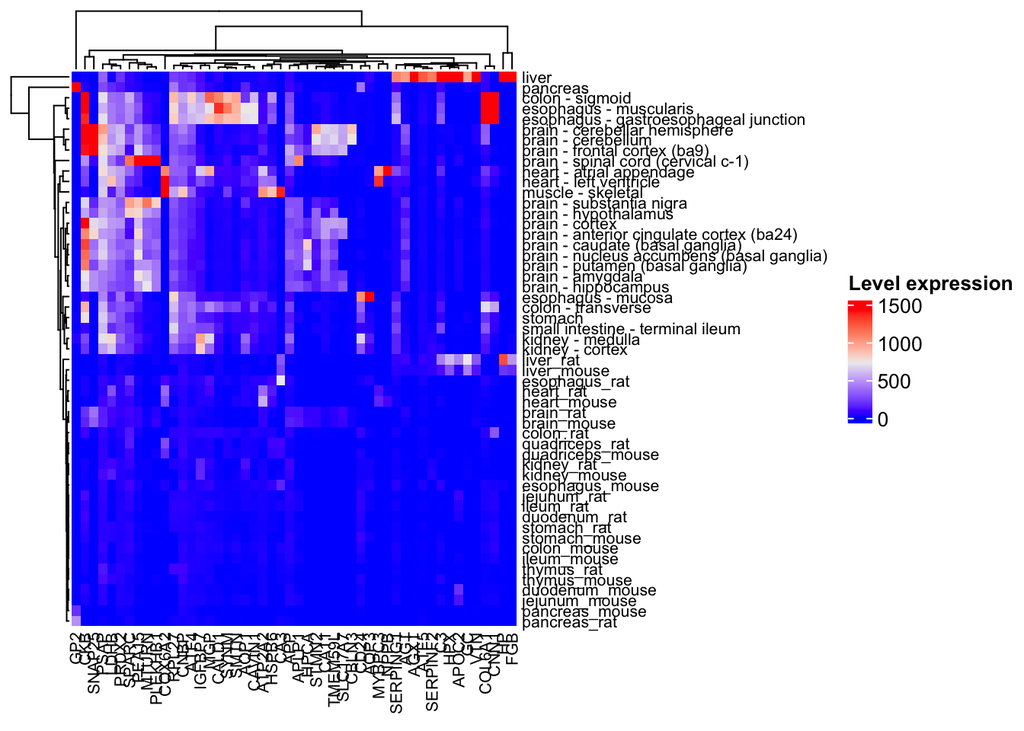

```
## The automatically generated colors map from the 1^st and 99^th of the
## values in the matrix. There are outliers in the matrix whose patterns
## might be hidden by this color mapping. You can manually set the color
## to `col` argument.
##
## Use `suppressMessages()` to turn off this message.
```

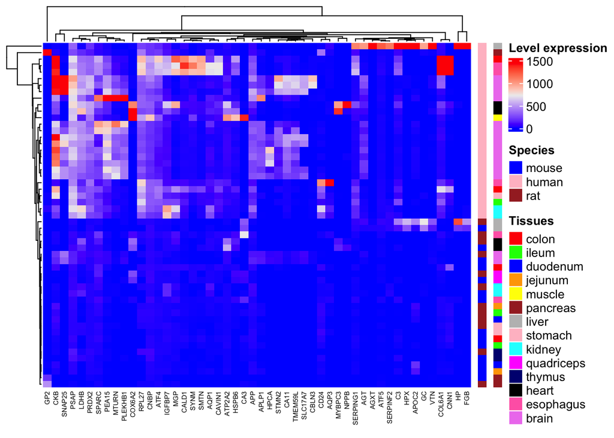

- Observing the final heatmap it is evident the same as it was observed by clustering. Human tissues are all clustered together as one groups, while the mouse and rat tissues are combined. On the other side, tissues are grouped together correctly which we can see from the second annotation. Additionally, “ensembl_gene_IDs” have been changed to gene symbols, so that it is more clear what are the genes that contributed to making this heatmap.

# Exercise 2: Dimensionality reduction

## PCA

With the gene expression for different tissues and models, perform a PCA on the data and visualize the results (PC1 and PC2, and also, PC3 ). Label the points in the plot with their respective tissues/models.

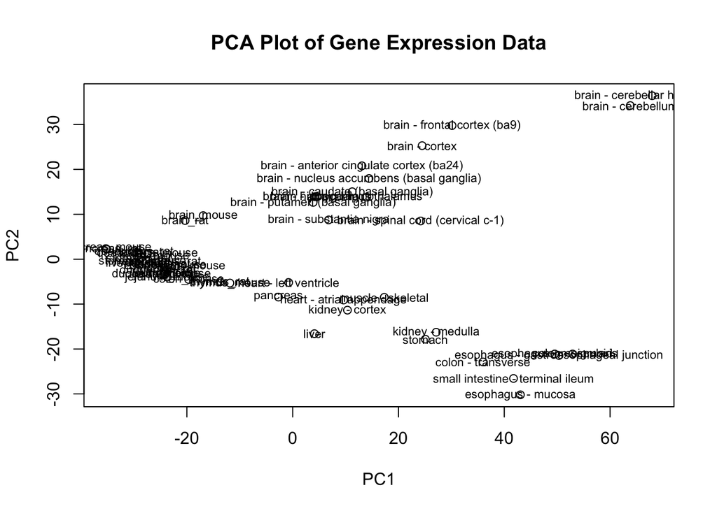

```
## integer(0)
```

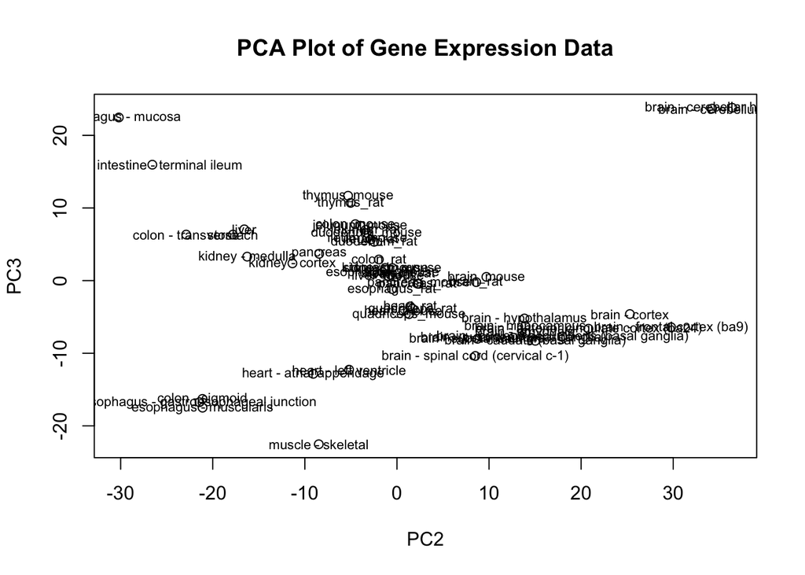

```
## integer(0)
```

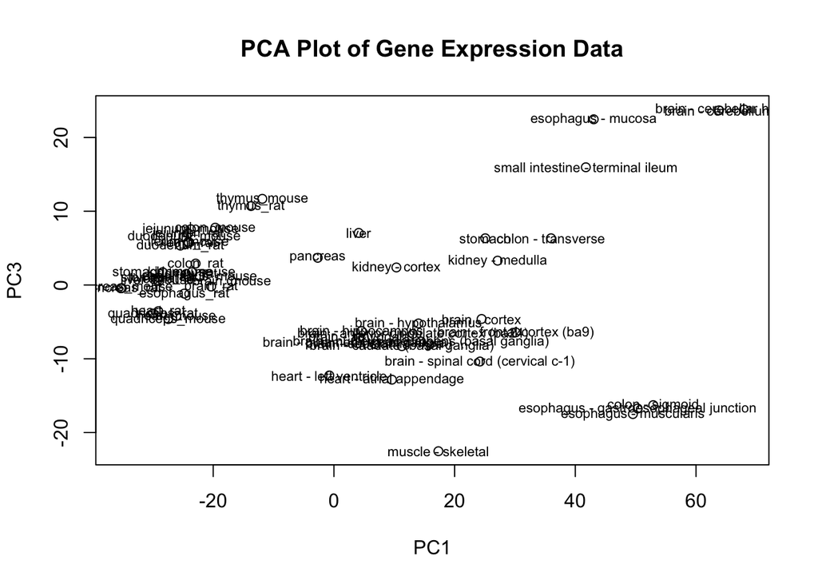

```
## integer(0)
```

### Visualize the data using the PC1 and PC2 again, but this time, color the observations by cluster, using the k means clusters, with k of your choice. Produce a caption for the plot

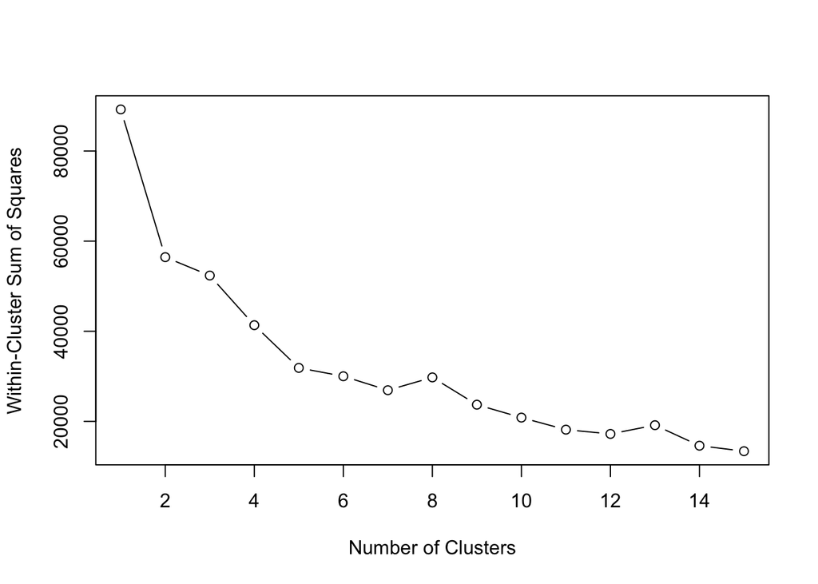

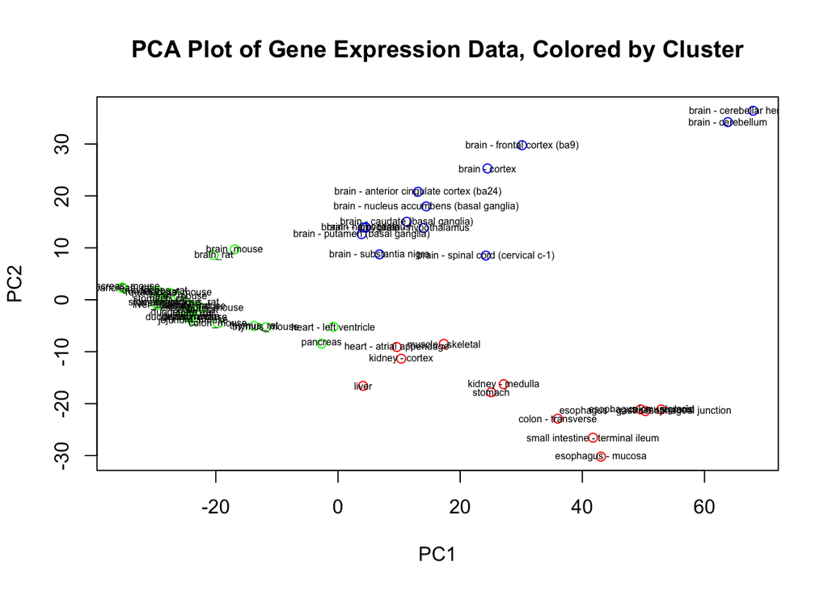

```
## integer(0)
```

### What are the top 50 genes that contribute to the PC1? Are they the same genes that are more variable according to the exercise 1?

- By using the function get_pca_var() from library(factoextra) to extract top 50 variable genes from pca and then afterwards merging the dataframe with the data frame of top 50 variable genes from the exercise 1, the result seems to be “0” meaning that there are no same genes more variable while comparing pca and those from the first exercise.

## tSNE

Perform t-SNE on the dataset and visualize the results. Test at least 2 perplexity values.

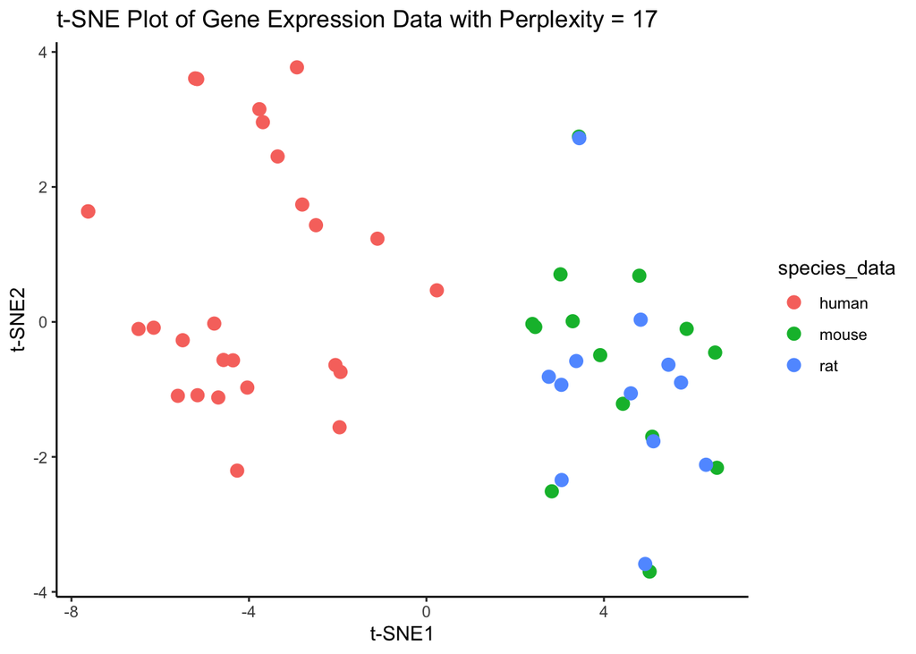

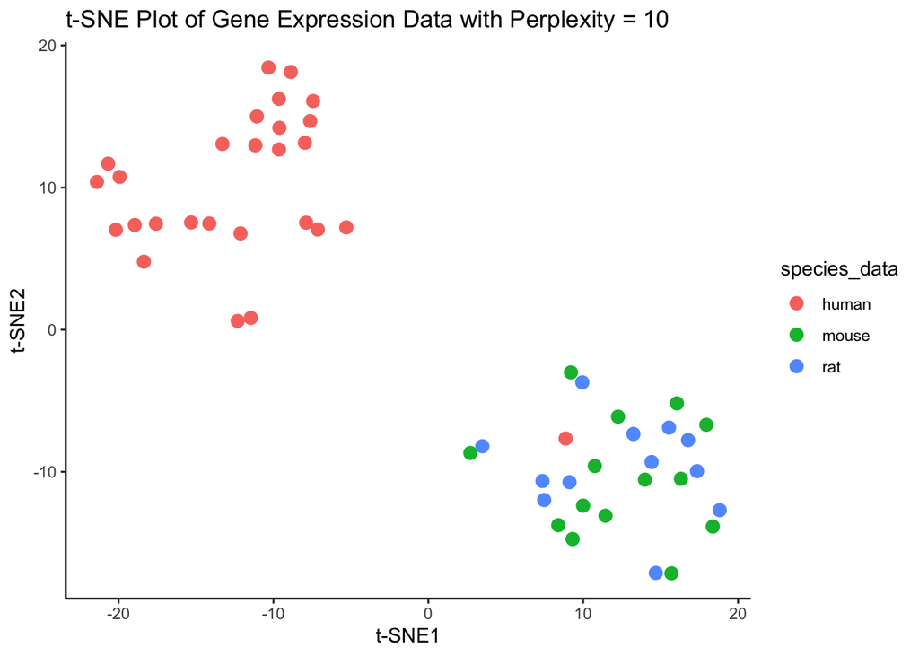

# session info

R version 4.2.1 (2022-06-23) Platform: x86_64-apple-darwin17.0 (64-bit) Running under: macOS Big Sur … 10.16

Matrix products: default BLAS: /Library/Frameworks/R.framework/Versions/4.2/Resources/lib/libRblas.0.dylib LAPACK: /Library/Frameworks/R.framework/Versions/4.2/Resources/lib/libRlapack.dylib

locale: [1] en_GB.UTF-8/en_GB.UTF-8/en_GB.UTF-8/C/en_GB.UTF-8/en_GB.UTF-8

attached base packages: [1] grid stats graphics grDevices utils datasets methods  
[8] base

other attached packages: [1] Rtsne_0.16 ComplexHeatmap_2.12.1 genefilter_1.78.0  
[4] factoextra_1.0.7 forcats_1.0.0 stringr_1.5.0  
[7] purrr_1.0.1 readr_2.1.4 tidyr_1.3.0  
[10] ggplot2_3.4.1 tidyverse_1.3.2 dendextend_1.16.0  
[13] tibble_3.1.8 biomaRt_2.52.0 rafalib_1.0.0  
[16] dplyr_1.1.0 magrittr_2.0.3

loaded via a namespace (and not attached): [1] googledrive_2.0.0 colorspace_2.1-0 ggsignif_0.6.4  
[4] rjson_0.2.21 ellipsis_0.3.2 circlize_0.4.15  
[7] XVector_0.36.0 GlobalOptions_0.1.2 fs_1.6.1  
[10] clue_0.3-64 rstudioapi_0.14 farver_2.1.1  
[13] ggpubr_0.6.0 ggrepel_0.9.3 bit64_4.0.5  
[16] AnnotationDbi_1.58.0 fansi_1.0.4 lubridate_1.9.2  
[19] xml2_1.3.3 codetools_0.2-19 splines_4.2.1  
[22] doParallel_1.0.17 cachem_1.0.6 knitr_1.42  
[25] jsonlite_1.8.4 broom_1.0.3 annotate_1.74.0  
[28] cluster_2.1.4 dbplyr_2.3.0 png_0.1-8  
[31] compiler_4.2.1 httr_1.4.4 backports_1.4.1  
[34] assertthat_0.2.1 Matrix_1.5-3 fastmap_1.1.0  
[37] gargle_1.3.0 cli_3.6.0 htmltools_0.5.4  
[40] prettyunits_1.1.1 tools_4.2.1 gtable_0.3.1  
[43] glue_1.6.2 GenomeInfoDbData_1.2.8 rappdirs_0.3.3  
[46] Rcpp_1.0.10 carData_3.0-5 Biobase_2.56.0  
[49] cellranger_1.1.0 jquerylib_0.1.4 vctrs_0.5.2  
[52] Biostrings_2.64.1 iterators_1.0.14 xfun_0.37  
[55] rvest_1.0.3 timechange_0.2.0 lifecycle_1.0.3  
[58] rstatix_0.7.2 XML_3.99-0.13 googlesheets4_1.0.1  
[61] zlibbioc_1.42.0 scales_1.2.1 hms_1.1.2  
[64] parallel_4.2.1 RColorBrewer_1.1-3 yaml_2.3.7  
[67] curl_5.0.0 memoise_2.0.1 gridExtra_2.3  
[70] sass_0.4.5 stringi_1.7.12 RSQLite_2.2.20  
[73] highr_0.10 S4Vectors_0.34.0 foreach_1.5.2  
[76] BiocGenerics_0.42.0 filelock_1.0.2 shape_1.4.6  
[79] GenomeInfoDb_1.32.4 rlang_1.0.6 pkgconfig_2.0.3  
[82] bitops_1.0-7 matrixStats_0.63.0 evaluate_0.20  
[85] lattice_0.20-45 labeling_0.4.2 bit_4.0.5  
[88] tidyselect_1.2.0 R6_2.5.1 IRanges_2.30.1  
[91] generics_0.1.3 DBI_1.1.3 pillar_1.8.1  
[94] haven_2.5.1 withr_2.5.0 abind_1.4-5  
[97] survival_3.5-3 KEGGREST_1.36.3 RCurl_1.98-1.10  
[100] car_3.1-1 modelr_0.1.10 crayon_1.5.2  
[103] utf8_1.2.3 BiocFileCache_2.4.0 tzdb_0.3.0  
[106] rmarkdown_2.20 viridis_0.6.2 GetoptLong_1.0.5  
[109] progress_1.2.2 readxl_1.4.2 blob_1.2.3  
[112] reprex_2.0.2 digest_0.6.31 xtable_1.8-4  
[115] stats4_4.2.1 munsell_0.5.0 viridisLite_0.4.1  
[118] bslib_0.4.2